# Tuning text models

J.H AHN

2022 2 15

Source: https://www.tidymodels.org/learn/work/tune-text/

**학습목표**

Prepare text data for predictive modeling and tune with both grid and iterative search.

## Introduction

이 문서의 코드를 사용하려면 `stopwords`, `textfeatures`, `textrecipes` 및 `tintymodels` 패키지를 설치해야 합니다.

이 문서에서는 텍스트 데이터에 대한 모델 학습 및 조정을 위한 고급 예제를 보여줍니다. 텍스트 데이터는 모델링에서 계산할 준비가 되도록 처리되고 숫자 표현으로 변환되어야 합니다. Tidymodels에서 우리는 이 전처리를 위한 recipe를 사용합니다. 이 문서는 또한 나중에 사용하기 위해 조정하는 동안 각 모델 적합(model fit)에서 정보를 추출하는 방법을 보여줍니다.

## Text as data

여기서 사용할 텍스트 데이터는 아마존에서 가져온 것이다.

> This dataset consists of reviews of fine foods from amazon. The data span a period of  
> more than 10 years, including all ~500,000 reviews up to October 2012. Reviews  
> include product and user information, ratings, and a plaintext review.

예제에서는 원본 소스(https://snap.stanford.edu/data/web-FineFoods.html) 에서 전체 리뷰의 작은 하위 집합을 사용합니다. 5,000개의 무작위 제품에서 단일 리뷰를 샘플링하고 이 데이터의 80%를 훈련 세트에 할당하고 나머지 1,000개 리뷰는 테스트 세트에 할당했습니다.

product에 대한 열, review 텍스트에 대한 열, 결과 변수에 대한 요인 열이 있습니다. 결과는 리뷰어가 제품에 별 5개 등급을 부여했는지 여부입니다.

```r
library(tidymodels)
data("small_fine_foods")

training_data
```

```
## # A tibble: 4,000 x 3
##    product    review                                                       score
##    <chr>      <chr>                                                        <fct>
##  1 B000J0LSBG "this stuff is  not stuffing  its  not good at all  save yo~ other
##  2 B000EYLDYE "I absolutely LOVE this dried fruit.  LOVE IT.  Whenever I ~ great
##  3 B0026LIO9A "GREAT DEAL, CONVENIENT TOO.  Much cheaper than WalMart and~ great
##  4 B00473P8SK "Great flavor, we go through a ton of this sauce! I discove~ great
##  5 B001SAWTNM "This is excellent salsa/hot sauce, but you can get it for ~ great
##  6 B000FAG90U "Again, this is the best dogfood out there.  One suggestion~ great
##  7 B006BXTCEK "The box I received was filled with teas, hot chocolates, a~ other
##  8 B002GWH5OY "This is delicious coffee which compares favorably with muc~ great
##  9 B003R0MFYY "Don't let these little tiny cans fool you.  They pack a lo~ great
## 10 B001EO5ZXI "One of the nicest, smoothest cup of chai I've made. Nice m~ great
## # ... with 3,990 more rows
```

예제의 모델링 목표는 review 텍스트에서 모델링 기능을 만들어 리뷰가 별점 5개인지 여부를 예측하는 것입니다.

## Inputs for the search

아마도 우리가 자주 다루는 표 형식의 데이터보다 텍스트는 모델링을 위한 예측 데이터로 사용하기 위해 많이 처리되어야 합니다. 모델링을 위해 텍스트를 처리하고 준비하는 방법에는 여러 가지가 있습니다. 여러 단계를 함께 추가하여 다양한 기능을 생성해 보겠습니다.

- 단어 수, 공백, 소문자 또는 대문자, URL 등과 같은 초기 개수 기반 기능 세트를 생성합니다. 이를 위해 `textfeatures` 패키지를 사용할 수 있습니다.
- 텍스트를 토큰화합니다(즉, 텍스트를 단어와 같은 더 작은 구성요소로 나눕니다).
- ““,”an”, “of” 등과 같은 불용어를 제거합니다.
- 가능한 경우 공통 루트에 토큰을 stem(https://smltar.com/stemming.html) 합니다.
- 서명된 이진 해시 함수(https://bookdown.org/max/FES/encoding-predictors-with-many-categories.html) 를 통해 토큰을 더미 변수로 변환합니다.
- 선택적으로 Yeo-Johnson변환(https://bookdown.org/max/FES/numeric-one-to-one.html) 을 사용하여 토큰이 아닌 기능(소문자 수와 같은 개수 기반 기능)을 보다 대칭적인 상태로 변환합니다.
- 단일 고유 값이 있는 예측 변수를 제거합니다.
- 모든 예측 변수를 중심에 놓고 척도화합니다.

```
두 가지 종류의 기능으로 끝납니다.

- 자릿수 또는 구두점 문자와 같은 카운트 기반 기능에 대한 dummy/indicator 변수
- "salsa" 또는 "delicious"과 같은 토큰에 대한 해시 기능.
```

이러한 전처리 단계(예: 형태소 분석) 중 일부는 좋은 아이디어일 수도 있고 아닐 수도 있지만 그 효과에 대한 완전한 논의는 이 기사의 범위를 벗어납니다. 이 전처리 방식에서 주요 조정 매개변수는 사용할 해싱 기능의 수입니다.

전처리 레시피 작성을 시작하기 전에 도우미 객체가 필요합니다. 예를 들어, Yeo-Johnson 변환의 경우 개수 기반 텍스트 기능 집합을 알아야 합니다.

```r
library(textfeatures)

count_functions
```

[output not shown]

[output cut: 305 more lines]

```
## function (x)
## {
##     fp <- c("about", "below", "excepting", "off", "toward", "above",
##         "beneath", "on", "under", "across", "from", "onto", "underneath",
##         "after", "between", "in", "out", "until", "against",
##         "beyond", "outside", "up", "along", "but", "inside",
##         "over", "upon", "among", "by", "past", "around", "concerning",
##         "regarding", "with", "at", "despite", "into", "since",
##         "within", "down", "like", "through", "without", "before",
##         "during", "near", "throughout", "behind", "except", "of",
##         "to", "for")
##     purrr::map_int(x, ~sum(fp %in% .x, na.rm = TRUE))
## }
## <bytecode: 0x00000000294742e8>
## <environment: namespace:textfeatures>
```

```r
names(count_functions)
```

```
##  [1] "n_words"        "n_uq_words"     "n_charS"        "n_uq_charS"
##  [5] "n_digits"       "n_hashtags"     "n_uq_hashtags"  "n_mentions"
##  [9] "n_uq_mentions"  "n_commas"       "n_periods"      "n_exclaims"
## [13] "n_extraspaces"  "n_caps"         "n_lowers"       "n_urls"
## [17] "n_uq_urls"      "n_nonasciis"    "n_puncts"       "politeness"
## [21] "first_person"   "first_personp"  "second_person"  "second_personp"
## [25] "third_person"   "to_be"          "prepositions"
```

```r
basics <- names(count_functions)
```

또한 기능 해시의 구현(the implementation of feature hashes)은 우리가 필요로 하는 바이너리 값을 생성하지 않습니다. 아래 짧은 코드의 함수는 점수를 -1, 0 또는 1 값으로 변환하는 데 도움이 됩니다.

```r
binary_hash <- function(x) {
  x <- ifelse(x < 0, -1, x)
  x <- ifelse(x > 0, 1, x)
  x
}
```

이제 모든 것을 하나의 recipe에 넣어보자.

```r
library(textrecipes)

recipe(score ~ product + review, data = training_data) %>%
  # Do not use the product ID as a predictor
  update_role(product, new_role = "id") %>%
  # Make a copy of the raw text
  step_mutate(review_raw = review) %>%
  prep() %>% juice()
```

```
## # A tibble: 4,000 x 4
##    product    review                        score review_raw
##    <fct>      <fct>                         <fct> <fct>
##  1 B000J0LSBG "this stuff is  not stuffing~ other "this stuff is  not stuffing ~
##  2 B000EYLDYE "I absolutely LOVE this drie~ great "I absolutely LOVE this dried~
##  3 B0026LIO9A "GREAT DEAL, CONVENIENT TOO.~ great "GREAT DEAL, CONVENIENT TOO. ~
##  4 B00473P8SK "Great flavor, we go through~ great "Great flavor, we go through ~
##  5 B001SAWTNM "This is excellent salsa/hot~ great "This is excellent salsa/hot ~
##  6 B000FAG90U "Again, this is the best dog~ great "Again, this is the best dogf~
##  7 B006BXTCEK "The box I received was fill~ other "The box I received was fille~
##  8 B002GWH5OY "This is delicious coffee wh~ great "This is delicious coffee whi~
##  9 B003R0MFYY "Don't let these little tiny~ great "Don't let these little tiny ~
## 10 B001EO5ZXI "One of the nicest, smoothes~ great "One of the nicest, smoothest~
## # ... with 3,990 more rows
```

```r
recipe(score ~ product + review, data = training_data) %>%
  # Do not use the product ID as a predictor
  update_role(product, new_role = "id") %>%
  # Make a copy of the raw text
  step_mutate(review_raw = review) %>%
  # Compute the initial features. This removes the 'review_raw' column
  step_textfeature(review_raw) %>%
  prep() %>% juice()
```

```
## # A tibble: 4,000 x 30
##    product    review   score textfeature_revi~ textfeature_rev~ textfeature_rev~
##    <fct>      <fct>    <fct>             <int>            <int>            <int>
##  1 B000J0LSBG "this s~ other                13               12               50
##  2 B000EYLDYE "I abso~ great                93               72              410
##  3 B0026LIO9A "GREAT ~ great               102               88              516
##  4 B00473P8SK "Great ~ great                36               33              156
##  5 B001SAWTNM "This i~ great                18               18               77
##  6 B000FAG90U "Again,~ great                27               24              117
##  7 B006BXTCEK "The bo~ other                81               71              413
##  8 B002GWH5OY "This i~ great                51               47              260
##  9 B003R0MFYY "Don't ~ great                55               51              232
## 10 B001EO5ZXI "One of~ great                44               36              169
## # ... with 3,990 more rows, and 24 more variables:
## #   textfeature_review_raw_n_uq_charS <int>,
## #   textfeature_review_raw_n_digits <int>,
## #   textfeature_review_raw_n_hashtags <int>,
## #   textfeature_review_raw_n_uq_hashtags <int>,
## #   textfeature_review_raw_n_mentions <int>,
## #   textfeature_review_raw_n_uq_mentions <int>, ...
```

```r
recipe(score ~ product + review, data = training_data) %>%
  # Do not use the product ID as a predictor
  update_role(product, new_role = "id") %>%
  # Make a copy of the raw text
  step_mutate(review_raw = review) %>%
  # Compute the initial features. This removes the 'review_raw' column
  step_textfeature(review_raw) %>%
  # Make the feature names shorter
  step_rename_at(
    starts_with("textfeature_"),
    fn = ~ gsub("textfeature_review_raw_", "", .)
  ) %>%
  prep() %>% juice()
```

```
## # A tibble: 4,000 x 30
##    product    review        score n_words n_uq_words n_charS n_uq_charS n_digits
##    <fct>      <fct>         <fct>   <int>      <int>   <int>      <int>    <int>
##  1 B000J0LSBG "this stuff ~ other      13         12      50         17        0
##  2 B000EYLDYE "I absolutel~ great      93         72     410         38        0
##  3 B0026LIO9A "GREAT DEAL,~ great     102         88     516         49        3
##  4 B00473P8SK "Great flavo~ great      36         33     156         30        0
##  5 B001SAWTNM "This is exc~ great      18         18      77         28        4
##  6 B000FAG90U "Again, this~ great      27         24     117         28        0
##  7 B006BXTCEK "The box I r~ other      81         71     413         44        1
##  8 B002GWH5OY "This is del~ great      51         47     260         33        0
##  9 B003R0MFYY "Don't let t~ great      55         51     232         32        0
## 10 B001EO5ZXI "One of the ~ great      44         36     169         30        0
## # ... with 3,990 more rows, and 22 more variables: n_hashtags <int>,
## #   n_uq_hashtags <int>, n_mentions <int>, n_uq_mentions <int>, n_commas <int>,
## #   n_periods <int>, n_exclaims <int>, n_extraspaces <int>, n_caps <int>,
## #   n_lowers <int>, n_urls <int>, n_uq_urls <int>, n_nonasciis <int>,
## #   n_puncts <int>, politeness <dbl>, first_person <int>, first_personp <int>,
## #   second_person <int>, second_personp <int>, third_person <int>, to_be <int>,
## #   prepositions <int>
```

```r
recipe(score ~ product + review, data = training_data) %>%
  # Do not use the product ID as a predictor
  update_role(product, new_role = "id") %>%
  # Make a copy of the raw text
  step_mutate(review_raw = review) %>%
  # Compute the initial features. This removes the 'review_raw' column
  step_textfeature(review_raw) %>%
  # Make the feature names shorter
  step_rename_at(
    starts_with("textfeature_"),
    fn = ~ gsub("textfeature_review_raw_", "", .)
  ) %>%
  step_tokenize(review) %>%
  prep() %>% juice()
```

```
## # A tibble: 4,000 x 30
##    product          review score n_words n_uq_words n_charS n_uq_charS n_digits
##    <fct>         <tknlist> <fct>   <int>      <int>   <int>      <int>    <int>
##  1 B000J0LSBG  [13 tokens] other      13         12      50         17        0
##  2 B000EYLDYE  [94 tokens] great      93         72     410         38        0
##  3 B0026LIO9A [104 tokens] great     102         88     516         49        3
##  4 B00473P8SK  [36 tokens] great      36         33     156         30        0
##  5 B001SAWTNM  [19 tokens] great      18         18      77         28        4
##  6 B000FAG90U  [27 tokens] great      27         24     117         28        0
##  7 B006BXTCEK  [83 tokens] other      81         71     413         44        1
##  8 B002GWH5OY  [53 tokens] great      51         47     260         33        0
##  9 B003R0MFYY  [55 tokens] great      55         51     232         32        0
## 10 B001EO5ZXI  [45 tokens] great      44         36     169         30        0
## # ... with 3,990 more rows, and 22 more variables: n_hashtags <int>,
## #   n_uq_hashtags <int>, n_mentions <int>, n_uq_mentions <int>, n_commas <int>,
## #   n_periods <int>, n_exclaims <int>, n_extraspaces <int>, n_caps <int>,
## #   n_lowers <int>, n_urls <int>, n_uq_urls <int>, n_nonasciis <int>,
## #   n_puncts <int>, politeness <dbl>, first_person <int>, first_personp <int>,
## #   second_person <int>, second_personp <int>, third_person <int>, to_be <int>,
## #   prepositions <int>
```

```r
recipe(score ~ product + review, data = training_data) %>%
  # Do not use the product ID as a predictor
  update_role(product, new_role = "id") %>%
  # Make a copy of the raw text
  step_mutate(review_raw = review) %>%
  # Compute the initial features. This removes the 'review_raw' column
  step_textfeature(review_raw) %>%
  # Make the feature names shorter
  step_rename_at(
    starts_with("textfeature_"),
    fn = ~ gsub("textfeature_review_raw_", "", .)
  ) %>%
  step_tokenize(review) %>%
  step_stopwords(review) %>%
  prep() %>% juice()
```

```
## # A tibble: 4,000 x 30
##    product         review score n_words n_uq_words n_charS n_uq_charS n_digits
##    <fct>        <tknlist> <fct>   <int>      <int>   <int>      <int>    <int>
##  1 B000J0LSBG  [5 tokens] other      13         12      50         17        0
##  2 B000EYLDYE [54 tokens] great      93         72     410         38        0
##  3 B0026LIO9A [66 tokens] great     102         88     516         49        3
##  4 B00473P8SK [20 tokens] great      36         33     156         30        0
##  5 B001SAWTNM [11 tokens] great      18         18      77         28        4
##  6 B000FAG90U [12 tokens] great      27         24     117         28        0
##  7 B006BXTCEK [52 tokens] other      81         71     413         44        1
##  8 B002GWH5OY [30 tokens] great      51         47     260         33        0
##  9 B003R0MFYY [31 tokens] great      55         51     232         32        0
## 10 B001EO5ZXI [24 tokens] great      44         36     169         30        0
## # ... with 3,990 more rows, and 22 more variables: n_hashtags <int>,
## #   n_uq_hashtags <int>, n_mentions <int>, n_uq_mentions <int>, n_commas <int>,
## #   n_periods <int>, n_exclaims <int>, n_extraspaces <int>, n_caps <int>,
## #   n_lowers <int>, n_urls <int>, n_uq_urls <int>, n_nonasciis <int>,
## #   n_puncts <int>, politeness <dbl>, first_person <int>, first_personp <int>,
## #   second_person <int>, second_personp <int>, third_person <int>, to_be <int>,
## #   prepositions <int>
```

```r
recipe(score ~ product + review, data = training_data) %>%
  # Do not use the product ID as a predictor
  update_role(product, new_role = "id") %>%
  # Make a copy of the raw text
  step_mutate(review_raw = review) %>%
  # Compute the initial features. This removes the 'review_raw' column
  step_textfeature(review_raw) %>%
  # Make the feature names shorter
  step_rename_at(
    starts_with("textfeature_"),
    fn = ~ gsub("textfeature_review_raw_", "", .)
  ) %>%
  step_tokenize(review) %>%
  step_stopwords(review) %>%
  step_stem(review) %>%
  prep() %>% juice() # %>% pull(review)
```

```
## # A tibble: 4,000 x 30
##    product         review score n_words n_uq_words n_charS n_uq_charS n_digits
##    <fct>        <tknlist> <fct>   <int>      <int>   <int>      <int>    <int>
##  1 B000J0LSBG  [5 tokens] other      13         12      50         17        0
##  2 B000EYLDYE [54 tokens] great      93         72     410         38        0
##  3 B0026LIO9A [66 tokens] great     102         88     516         49        3
##  4 B00473P8SK [20 tokens] great      36         33     156         30        0
##  5 B001SAWTNM [11 tokens] great      18         18      77         28        4
##  6 B000FAG90U [12 tokens] great      27         24     117         28        0
##  7 B006BXTCEK [52 tokens] other      81         71     413         44        1
##  8 B002GWH5OY [30 tokens] great      51         47     260         33        0
##  9 B003R0MFYY [31 tokens] great      55         51     232         32        0
## 10 B001EO5ZXI [24 tokens] great      44         36     169         30        0
## # ... with 3,990 more rows, and 22 more variables: n_hashtags <int>,
## #   n_uq_hashtags <int>, n_mentions <int>, n_uq_mentions <int>, n_commas <int>,
## #   n_periods <int>, n_exclaims <int>, n_extraspaces <int>, n_caps <int>,
## #   n_lowers <int>, n_urls <int>, n_uq_urls <int>, n_nonasciis <int>,
## #   n_puncts <int>, politeness <dbl>, first_person <int>, first_personp <int>,
## #   second_person <int>, second_personp <int>, third_person <int>, to_be <int>,
## #   prepositions <int>
```

```r
library(Matrix)
library(rsparse)
library(lgr)
recipe(score ~ product + review, data = training_data) %>%
  update_role(product, new_role = "id") %>%
  step_mutate(review_raw = review) %>%
  step_textfeature(review_raw) %>%
  step_rename_at(
    starts_with("textfeature_"),
    fn = ~ gsub("textfeature_review_raw_", "", .)
  ) %>%
  step_tokenize(review) %>%
  step_stopwords(review) %>%
  step_stem(review) %>%
  step_texthash('review') %>%
  prep() %>% juice() # %>% pull(review)
```

```
## # A tibble: 4,000 x 1,053
##    review_hash0001 review_hash0002 review_hash0003 review_hash0004
##              <dbl>           <dbl>           <dbl>           <dbl>
##  1               0               0               0               0
##  2               0               0               0               0
##  3               0               0               0               1
##  4               0               0               0               0
##  5               0               0               0               0
##  6               0               0               0               0
##  7               0              -1               0               0
##  8               0               0               0               0
##  9               0               0               0               0
## 10               0               0               0               0
## # ... with 3,990 more rows, and 1,049 more variables: review_hash0005 <dbl>,
## #   review_hash0006 <dbl>, review_hash0007 <dbl>, review_hash0008 <dbl>,
## #   review_hash0009 <dbl>, review_hash0010 <dbl>, review_hash0011 <dbl>,
## #   review_hash0012 <dbl>, review_hash0013 <dbl>, review_hash0014 <dbl>,
## #   review_hash0015 <dbl>, review_hash0016 <dbl>, review_hash0017 <dbl>,
## #   review_hash0018 <dbl>, review_hash0019 <dbl>, review_hash0020 <dbl>,
## #   review_hash0021 <dbl>, review_hash0022 <dbl>, review_hash0023 <dbl>, ...
```

```r
recipe(score ~ product + review, data = training_data) %>%
  update_role(product, new_role = "id") %>%
  step_mutate(review_raw = review) %>%
  step_textfeature(review_raw) %>%
  step_rename_at(
    starts_with("textfeature_"),
    fn = ~ gsub("textfeature_review_raw_", "", .)
  ) %>%
  step_tokenize(review) %>%
  step_stopwords(review) %>%
  step_stem(review) %>%
  step_texthash('review') %>%
  step_rename_at(starts_with("review_hash"), fn = ~ gsub("review_","", .)) %>%
  prep() %>% juice() # %>% pull(review)
```

```
## # A tibble: 4,000 x 1,053
##    hash0001 hash0002 hash0003 hash0004 hash0005 hash0006 hash0007 hash0008
##       <dbl>    <dbl>    <dbl>    <dbl>    <dbl>    <dbl>    <dbl>    <dbl>
##  1        0        0        0        0        0        0        0        0
##  2        0        0        0        0        1        0        0        0
##  3        0        0        0        1        0        0        0        0
##  4        0        0        0        0        0        0        0        0
##  5        0        0        0        0        0        0        0        0
##  6        0        0        0        0        0        0        0        0
##  7        0       -1        0        0        0        0       -1        0
##  8        0        0        0        0        0        0        0        0
##  9        0        0        0        0        0        0        0        0
## 10        0        0        0        0        0        0        0        0
## # ... with 3,990 more rows, and 1,045 more variables: hash0009 <dbl>,
## #   hash0010 <dbl>, hash0011 <dbl>, hash0012 <dbl>, hash0013 <dbl>,
## #   hash0014 <dbl>, hash0015 <dbl>, hash0016 <dbl>, hash0017 <dbl>,
## #   hash0018 <dbl>, hash0019 <dbl>, hash0020 <dbl>, hash0021 <dbl>,
## #   hash0022 <dbl>, hash0023 <dbl>, hash0024 <dbl>, hash0025 <dbl>,
## #   hash0026 <dbl>, hash0027 <dbl>, hash0028 <dbl>, hash0029 <dbl>,
## #   hash0030 <dbl>, hash0031 <dbl>, hash0032 <dbl>, hash0033 <dbl>, ...
```

```r
recipe(score ~ product + review, data = training_data) %>%
  update_role(product, new_role = "id") %>%
  step_mutate(review_raw = review) %>%
  step_textfeature(review_raw) %>%
  step_rename_at(
    starts_with("textfeature_"),
    fn = ~ gsub("textfeature_review_raw_", "", .)
  ) %>%
  step_tokenize(review) %>%
  step_stopwords(review) %>%
  step_stem(review) %>%
  step_texthash('review') %>%
  step_rename_at(starts_with("review_hash"), fn = ~ gsub("review_","", .)) %>%
  step_mutate_at(starts_with("hash"), fn = binary_hash) %>%
  prep() %>% juice() # %>% pull(review)
```

```
## # A tibble: 4,000 x 1,053
##    hash0001 hash0002 hash0003 hash0004 hash0005 hash0006 hash0007 hash0008
##       <dbl>    <dbl>    <dbl>    <dbl>    <dbl>    <dbl>    <dbl>    <dbl>
##  1        0        0        0        0        0        0        0        0
##  2        0        0        0        0        1        0        0        0
##  3        0        0        0        1        0        0        0        0
##  4        0        0        0        0        0        0        0        0
##  5        0        0        0        0        0        0        0        0
##  6        0        0        0        0        0        0        0        0
##  7        0       -1        0        0        0        0       -1        0
##  8        0        0        0        0        0        0        0        0
##  9        0        0        0        0        0        0        0        0
## 10        0        0        0        0        0        0        0        0
## # ... with 3,990 more rows, and 1,045 more variables: hash0009 <dbl>,
## #   hash0010 <dbl>, hash0011 <dbl>, hash0012 <dbl>, hash0013 <dbl>,
## #   hash0014 <dbl>, hash0015 <dbl>, hash0016 <dbl>, hash0017 <dbl>,
## #   hash0018 <dbl>, hash0019 <dbl>, hash0020 <dbl>, hash0021 <dbl>,
## #   hash0022 <dbl>, hash0023 <dbl>, hash0024 <dbl>, hash0025 <dbl>,
## #   hash0026 <dbl>, hash0027 <dbl>, hash0028 <dbl>, hash0029 <dbl>,
## #   hash0030 <dbl>, hash0031 <dbl>, hash0032 <dbl>, hash0033 <dbl>, ...
```

```r
recipe(score ~ product + review, data = training_data) %>%
  update_role(product, new_role = "id") %>%
  step_mutate(review_raw = review) %>%
  step_textfeature(review_raw) %>%
  step_rename_at(
    starts_with("textfeature_"),
    fn = ~ gsub("textfeature_review_raw_", "", .)
  ) %>%
  step_tokenize(review) %>%
  step_stopwords(review) %>%
  step_stem(review) %>%
  step_texthash('review') %>%
  step_rename_at(starts_with("review_hash"), fn = ~ gsub("review_","", .)) %>%
  step_mutate_at(starts_with("hash"), fn = binary_hash) %>%
  step_YeoJohnson(one_of(!!basics)) %>%
  prep() %>% juice() # %>% pull(review)
```

```
## # A tibble: 4,000 x 1,053
##    hash0001 hash0002 hash0003 hash0004 hash0005 hash0006 hash0007 hash0008
##       <dbl>    <dbl>    <dbl>    <dbl>    <dbl>    <dbl>    <dbl>    <dbl>
##  1        0        0        0        0        0        0        0        0
##  2        0        0        0        0        1        0        0        0
##  3        0        0        0        1        0        0        0        0
##  4        0        0        0        0        0        0        0        0
##  5        0        0        0        0        0        0        0        0
##  6        0        0        0        0        0        0        0        0
##  7        0       -1        0        0        0        0       -1        0
##  8        0        0        0        0        0        0        0        0
##  9        0        0        0        0        0        0        0        0
## 10        0        0        0        0        0        0        0        0
## # ... with 3,990 more rows, and 1,045 more variables: hash0009 <dbl>,
## #   hash0010 <dbl>, hash0011 <dbl>, hash0012 <dbl>, hash0013 <dbl>,
## #   hash0014 <dbl>, hash0015 <dbl>, hash0016 <dbl>, hash0017 <dbl>,
## #   hash0018 <dbl>, hash0019 <dbl>, hash0020 <dbl>, hash0021 <dbl>,
## #   hash0022 <dbl>, hash0023 <dbl>, hash0024 <dbl>, hash0025 <dbl>,
## #   hash0026 <dbl>, hash0027 <dbl>, hash0028 <dbl>, hash0029 <dbl>,
## #   hash0030 <dbl>, hash0031 <dbl>, hash0032 <dbl>, hash0033 <dbl>, ...
```

```r
recipe(score ~ product + review, data = training_data) %>%
  update_role(product, new_role = "id") %>%
  step_mutate(review_raw = review) %>%
  step_textfeature(review_raw) %>%
  step_rename_at(
    starts_with("textfeature_"),
    fn = ~ gsub("textfeature_review_raw_", "", .)
  ) %>%
  step_tokenize(review) %>%
  step_stopwords(review) %>%
  step_stem(review) %>%
  step_texthash('review') %>%
  step_rename_at(starts_with("review_hash"), fn = ~ gsub("review_","", .)) %>%
  step_mutate_at(starts_with("hash"), fn = binary_hash) %>%
  step_YeoJohnson(one_of(!!basics)) %>%
  step_zv(all_predictors()) %>%
  prep() %>% juice() # %>% pull(review)
```

```
## # A tibble: 4,000 x 1,043
##    hash0001 hash0002 hash0003 hash0004 hash0005 hash0006 hash0007 hash0008
##       <dbl>    <dbl>    <dbl>    <dbl>    <dbl>    <dbl>    <dbl>    <dbl>
##  1        0        0        0        0        0        0        0        0
##  2        0        0        0        0        1        0        0        0
##  3        0        0        0        1        0        0        0        0
##  4        0        0        0        0        0        0        0        0
##  5        0        0        0        0        0        0        0        0
##  6        0        0        0        0        0        0        0        0
##  7        0       -1        0        0        0        0       -1        0
##  8        0        0        0        0        0        0        0        0
##  9        0        0        0        0        0        0        0        0
## 10        0        0        0        0        0        0        0        0
## # ... with 3,990 more rows, and 1,035 more variables: hash0009 <dbl>,
## #   hash0010 <dbl>, hash0011 <dbl>, hash0012 <dbl>, hash0013 <dbl>,
## #   hash0014 <dbl>, hash0015 <dbl>, hash0016 <dbl>, hash0017 <dbl>,
## #   hash0018 <dbl>, hash0019 <dbl>, hash0020 <dbl>, hash0021 <dbl>,
## #   hash0022 <dbl>, hash0023 <dbl>, hash0024 <dbl>, hash0025 <dbl>,
## #   hash0026 <dbl>, hash0027 <dbl>, hash0028 <dbl>, hash0029 <dbl>,
## #   hash0030 <dbl>, hash0031 <dbl>, hash0032 <dbl>, hash0033 <dbl>, ...
```

```r
pre_proc <-
  recipe(score ~ product + review, data = training_data) %>%
  update_role(product, new_role = "id") %>%
  step_mutate(review_raw = review) %>%
  step_textfeature(review_raw) %>%
  step_rename_at(
    starts_with("textfeature_"),
    fn = ~ gsub("textfeature_review_raw_", "", .)
  ) %>%
  step_tokenize(review) %>%
  step_stopwords(review) %>%
  step_stem(review) %>%
  step_texthash('review', signed = TRUE, num_terms = tune()) %>%
  step_rename_at(starts_with("review_hash"), fn = ~ gsub("review_","", .)) %>%
  step_mutate_at(starts_with("hash"), fn = binary_hash) %>%
  step_YeoJohnson(one_of(!!basics)) %>%
  step_zv(all_predictors()) %>%
  step_normalize(all_predictors())

pre_proc
```

```
## Recipe
##
## Inputs:
##
##       role #variables
##         id          1
##    outcome          1
##  predictor          1
##
## Operations:
##
## Variable mutation
## Text feature extraction for review_raw
## Variable renaming for starts_with("textfeature_")
## Tokenization for review
## Stop word removal for review
## Stemming for review
## Feature hashing with "review"
## Variable renaming for starts_with("review_hash")
## Variable mutation for starts_with("hash")
## Yeo-Johnson transformation on one_of(<chr: "n_words", "n_uq_words", ...
## Zero variance filter on all_predictors()
## Centering and scaling for all_predictors()
```

**step_texthash(‘review’, signed = TRUE, num_terms = tune())**

Here is where the tuning parameter is declared

num_terms = tune()을 사용하면서 prep()를 하면 *Error: You cannot `prep()` a tuneable recipe.* 가 발생

**step_mutate_at(starts_with(“hash”), fn = binary_hash)**

Convert the features from counts to values of -1, 0, or 1

**step_YeoJohnson(one_of(!!basics))**

Transform the initial feature set

전처리 방법은 길고 복잡하지만(일반적으로 텍스트 데이터 작업에 일반적임) 우리가 사용할 모델은 더 간단합니다. 정규화된 로지스틱 회귀 모델을 고수합시다.

```r
lr_mod <-
  logistic_reg(penalty = tune(), mixture = tune()) %>%
  set_engine("glmnet")

lr_mod
```

```
## Logistic Regression Model Specification (classification)
##
## Main Arguments:
##   penalty = tune()
##   mixture = tune()
##
## Computational engine: glmnet
```

이 데이터 분석에는 세 가지 조정 매개변수가 있습니다.

- `num_terms`, 생성할 기능 해시 변수의 수
- `penalty`, 모델의 정규화 양
- `mixture`, L1 정규화 비율

## Resampling

여기에는 10겹 리샘플링이 성능을 추정하기 위해 한 번에 400개의 리뷰를 보유할 수 있을 만큼 충분한 데이터가 있습니다. 이 많은 관측치를 사용한 성능 추정치는 모델을 측정하고 조정하기에 충분히 낮은 노이즈를 가지고 있습니다.

```r
set.seed(8935)
folds <- vfold_cv(training_data)
folds
```

```
## #  10-fold cross-validation
## # A tibble: 10 x 2
##    splits             id
##    <list>             <chr>
##  1 <split [3600/400]> Fold01
##  2 <split [3600/400]> Fold02
##  3 <split [3600/400]> Fold03
##  4 <split [3600/400]> Fold04
##  5 <split [3600/400]> Fold05
##  6 <split [3600/400]> Fold06
##  7 <split [3600/400]> Fold07
##  8 <split [3600/400]> Fold08
##  9 <split [3600/400]> Fold09
## 10 <split [3600/400]> Fold10
```

## Grid search

```r
five_star_grid <-
  crossing(
    penalty = 10^seq(-3, 0, length = 30),
    mixture = c(0.01, 0.25, 0.50, 0.75, 1),
    num_terms = 2^c(8, 10, 12)
  )

five_star_grid
```

```
## # A tibble: 450 x 3
##    penalty mixture num_terms
##      <dbl>   <dbl>     <dbl>
##  1   0.001    0.01       256
##  2   0.001    0.01      1024
##  3   0.001    0.01      4096
##  4   0.001    0.25       256
##  5   0.001    0.25      1024
##  6   0.001    0.25      4096
##  7   0.001    0.5        256
##  8   0.001    0.5       1024
##  9   0.001    0.5       4096
## 10   0.001    0.75       256
## # ... with 440 more rows
```

각 glmnet 모델에 대한 패널티 값으로 예측 변수의 수에 대한 정보를 저장합시다. 이는 패널티 값에서 사용된 기능의 수를 이해하는 데 도움이 됩니다. 추출 기능을 사용하여 다음을 수행하십시오.

**x** will be a workflow object  
**df** is the number of model terms for each penalty value

```r
glmnet_vars <- function(x) {
  mod <- extract_model(x)
  tibble(penalty = mod$lambda, num_vars = mod$df)
}

ctrl <- control_grid(extract = glmnet_vars, verbose = TRUE)
```

이제 Grid search를 실행해 보자.

```r
roc_scores <- metric_set(roc_auc)

roc_scores
```

```
## # A tibble: 1 x 3
##   metric  class       direction
##   <chr>   <chr>       <chr>
## 1 roc_auc prob_metric maximize
```

```r
doParallel::registerDoParallel()

set.seed(1559)

five_star_glmnet <-
  tune_grid(
    object = lr_mod,
    preprocessor = pre_proc,
    resamples = folds,
    grid = five_star_grid,
    metrics = roc_scores,
    control = ctrl
  )

five_star_glmnet
```

```
## # Tuning results
## # 10-fold cross-validation
## # A tibble: 10 x 5
##    splits             id     .metrics           .notes           .extracts
##    <list>             <chr>  <list>             <list>           <list>
##  1 <split [3600/400]> Fold01 <tibble [450 x 7]> <tibble [1 x 1]> <tibble [450 x~
##  2 <split [3600/400]> Fold02 <tibble [450 x 7]> <tibble [1 x 1]> <tibble [450 x~
##  3 <split [3600/400]> Fold03 <tibble [450 x 7]> <tibble [1 x 1]> <tibble [450 x~
##  4 <split [3600/400]> Fold04 <tibble [450 x 7]> <tibble [1 x 1]> <tibble [450 x~
##  5 <split [3600/400]> Fold05 <tibble [450 x 7]> <tibble [1 x 1]> <tibble [450 x~
##  6 <split [3600/400]> Fold06 <tibble [450 x 7]> <tibble [1 x 1]> <tibble [450 x~
##  7 <split [3600/400]> Fold07 <tibble [450 x 7]> <tibble [1 x 1]> <tibble [450 x~
##  8 <split [3600/400]> Fold08 <tibble [450 x 7]> <tibble [1 x 1]> <tibble [450 x~
##  9 <split [3600/400]> Fold09 <tibble [450 x 7]> <tibble [1 x 1]> <tibble [450 x~
## 10 <split [3600/400]> Fold10 <tibble [450 x 7]> <tibble [1 x 1]> <tibble [450 x~
```

완료하는 데 시간이 걸렸습니다! 결과는 어떻게 됩니까? 각 조정 매개변수에 대한 ROC 곡선 아래 영역의 리샘플링 추정치를 구해 보겠습니다.

```r
grid_roc <-
  collect_metrics(five_star_glmnet) %>%
  arrange(desc(mean))

grid_roc
```

```
## # A tibble: 450 x 9
##    penalty mixture num_terms .metric .estimator  mean     n std_err .config
##      <dbl>   <dbl>     <dbl> <chr>   <chr>      <dbl> <int>   <dbl> <chr>
##  1  0.621     0.01      4096 roc_auc binary     0.818    10 0.00744 Preprocesso~
##  2  0.489     0.01      4096 roc_auc binary     0.818    10 0.00773 Preprocesso~
##  3  0.788     0.01      4096 roc_auc binary     0.817    10 0.00735 Preprocesso~
##  4  0.386     0.01      4096 roc_auc binary     0.816    10 0.00808 Preprocesso~
##  5  0.0356    0.25      4096 roc_auc binary     0.816    10 0.00759 Preprocesso~
##  6  0.0452    0.25      4096 roc_auc binary     0.815    10 0.00756 Preprocesso~
##  7  0.304     0.01      4096 roc_auc binary     0.814    10 0.00830 Preprocesso~
##  8  0.0174    0.5       4096 roc_auc binary     0.814    10 0.00779 Preprocesso~
##  9  0.0221    0.5       4096 roc_auc binary     0.814    10 0.00776 Preprocesso~
## 10  0.0281    0.25      4096 roc_auc binary     0.813    10 0.00787 Preprocesso~
## # ... with 440 more rows
```

최상의 결과는 상당히 높은 패널티 값을 가지며 ridge 패널티에 초점을 맞춥니다(즉, lasso의 L1 패널티를 통해 features 선택이 없음). 최고의 솔루션은 또한 가장 많은 해싱 값을 가지고 있다.

성능과 조정 매개변수 사이의 관계는 무엇입니까?

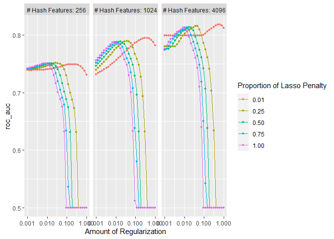

```r
autoplot(five_star_glmnet, metric = "roc_auc")
```

- 포함된 feature의 수에 따라 성능이 향상된다는 것을 확실히 알 수 있습니다. 위 예시에서는 사용 가능한 전체 데이터 세트의 작은 샘플을 사용했습니다. 더 많은 데이터가 사용되면 더 큰 feature set이 최적입니다.
- mixture 값이 더 큰(0.01보다 큰) 프로파일은 성능이 급격히 떨어집니다. 그게 뭐야? lasso penalty가 모델에서 너무 많은(아마도 모든) feature를 제거하는 경우입니다.
- 4096개 이상의 기능이 있는 패널은 성능이 거의 동일한 여러 매개변수 조합이 있음을 보여줍니다. 다른 mixture 값에 대한 최상의 성능 사이에는 큰 차이가 없습니다. 더 적은 수의 예측 변수를 포함하는 더 단순한 모델을 선택하기 위해 더 큰 혼합 값과 더 작은 페널티를 선택 해야 하는 경우가 만들어질 수 있습니다.
- 더 많은 실험이 수행된 경우 더 큰 feature set(4096개 이상)도 고려해야 합니다.

이 문서의 끝에 위에서 추출해 둔 glmnet component를 사용할 것이다.

## Directed search

베이지안 최적화로 시작했다면 어떨까요? 좋은 조건 세트가 더 효율적으로 발견되었을까요?

그리드 검색 결과를 보지 못했다고 가정해 봅시다. 공간 채우기 설계로 선택한 5가지 조정 매개변수 조합으로 가우스 프로세스 모델을 초기화합니다.

해시 용어의 수에 대해 custom한 `dials` 개체를 사용하는 것이 좋습니다 . 기본 개체인 `num_terms()`은 선형 범위를 사용하고 데이터를 사용하여 매개변수의 상한을 설정하려고 합니다. 대신에 매개변수 집합을 만들고 눈금을 `log2` 로 변경하고, 그리드 검색에서 사용된 것과 동일한 범위를 정의해 보겠습니다.

```r
# grid search:  num_terms = 2^c(8, 10, 12)
hash_range <- num_terms(c(8, 12), trans = log2_trans())

hash_range
```

```
## # Model Terms (quantitative)
## Transformer:  log-2
## Range (transformed scale): [8, 12]
```

이를 사용하려면 레시피와 `parsnip` 모델 개체를 워크플로에 병합해야 합니다. 이전에는 workflow를 만들지 않고 recipe에 바로 lr_mod를 사용했음.

```r
five_star_wflow <-
  workflow() %>%
  add_recipe(pre_proc) %>%
  add_model(lr_mod)

five_star_wflow
```

```
## == Workflow ====================================================================
## Preprocessor: Recipe
## Model: logistic_reg()
##
## -- Preprocessor ----------------------------------------------------------------
## 12 Recipe Steps
##
## * step_mutate()
## * step_textfeature()
## * step_rename_at()
## * step_tokenize()
## * step_stopwords()
## * step_stem()
## * step_texthash()
## * step_rename_at()
## * step_mutate_at()
## * step_YeoJohnson()
## * ...
## * and 2 more steps.
##
## -- Model -----------------------------------------------------------------------
## Logistic Regression Model Specification (classification)
##
## Main Arguments:
##   penalty = tune()
##   mixture = tune()
##
## Computational engine: glmnet
```

그런 다음 해당 매개변수 세트를 추출하고 조작할 수 있습니다.

```r
five_star_wflow %>%
  parameters()
```

```
## Collection of 3 parameters for tuning
##
##  identifier      type    object
##     penalty   penalty nparam[+]
##     mixture   mixture nparam[+]
##   num_terms num_terms nparam[+]
```

```r
five_star_wflow %>%
  parameters() %>%
  update(
    num_terms = hash_range,
    penalty = penalty(c(-3, 0)),
    mixture = mixture(c(0.05, 1.00))
  ) %>% pull()
```

```
## [[1]]
## Amount of Regularization (quantitative)
## Transformer:  log-10
## Range (transformed scale): [-3, 0]
##
## [[2]]
## Proportion of Lasso Penalty (quantitative)
## Range: [0.05, 1]
##
## [[3]]
## # Model Terms (quantitative)
## Transformer:  log-2
## Range (transformed scale): [8, 12]
```

```r
five_star_set <-
  five_star_wflow %>%
  parameters() %>%
  update(
    num_terms = hash_range,
    penalty = penalty(c(-3, 0)),
    mixture = mixture(c(0.05, 1.00))
  )

five_star_set
```

```
## Collection of 3 parameters for tuning
##
##  identifier      type    object
##     penalty   penalty nparam[+]
##     mixture   mixture nparam[+]
##   num_terms num_terms nparam[+]
```

이것은 `param_info`인수 를 통해 검색 기능에 전달됩니다.

초기 검색 라운드는 매개변수 공간 탐색에 더 치우칠 수 있습니다(현재 최상의 결과 근처에 머무르는 것과 반대). 예상되는 개선이 획득 기능으로 사용되는 경우 트레이드오프 값은 반복을 통해 탐색에서 활용으로 천천히 이동할 수 있습니다. ( 자세한 내용은 획득 기능(https://tune.tidymodels.org/articles/acquisition_functions.html) 에 대한 조정 비네트 참조). tune 패키지에는 이를 수행하는 데 도움 이 되는 내장 함수 `expo_decay()` 가 있습니다.

```r
trade_off_decay <- function(iter) {
  expo_decay(iter, start_val = 0.01, limit_val = 0, slope = 1/4)
}
```

이 값들을 이용해서 검색을 실행해보자.

```r
set.seed(12)

five_star_search <-
  tune_bayes(
    object = five_star_wflow,
    resamples = folds,
    iter = 30,
    param_info = five_star_set,
    initial = 5,
    metrics = roc_scores,
    objective = exp_improve(trade_off_decay),
    control = control_bayes(verbose = TRUE)
  )
```

```
## >  Generating a set of 5 initial parameter results
```

```
## √ Initialization complete
```

```
## Optimizing roc_auc using the expected improvement with variable trade-off
## values.
```

```
## -- Iteration 1 -----------------------------------------------------------------
```

```
## i Current best:      roc_auc=0.7559 (@iter 0)
```

```
## i Gaussian process model
```

```
## √ Gaussian process model
```

```
## i Generating 5000 candidates
```

```
## i Predicted candidates
```

```
## i Trade-off value: 0.01
```

```
## i penalty=0.00251, mixture=0.0528, num_terms=260
```

```
## i Estimating performance
```

```
## √ Estimating performance
```

```
## (x) Newest results:  roc_auc=0.7475 (+/-0.0102)
```

```
## -- Iteration 2 -----------------------------------------------------------------
```

```
## i Current best:      roc_auc=0.7559 (@iter 0)
```

```
## i Gaussian process model
```

```
## √ Gaussian process model
```

```
## i Generating 5000 candidates
```

```
## i Predicted candidates
```

```
## i Trade-off value: 0.007788
```

```
## i penalty=0.00389, mixture=0.616, num_terms=489
```

```
## i Estimating performance
```

```
## √ Estimating performance
```

```
## <3 Newest results:   roc_auc=0.7753 (+/-0.009)
```

```
## -- Iteration 3 -----------------------------------------------------------------
```

```
## i Current best:      roc_auc=0.7753 (@iter 2)
```

```
## i Gaussian process model
```

```
## √ Gaussian process model
```

```
## i Generating 5000 candidates
```

```
## i Predicted candidates
```

```
## i Trade-off value: 0.006065
```

```
## i penalty=0.00101, mixture=0.463, num_terms=517
```

```
## i Estimating performance
```

```
## √ Estimating performance
```

```
## (x) Newest results:  roc_auc=0.7456 (+/-0.0107)
```

```
## -- Iteration 4 -----------------------------------------------------------------
```

```
## i Current best:      roc_auc=0.7753 (@iter 2)
```

```
## i Gaussian process model
```

```
## √ Gaussian process model
```

```
## i Generating 5000 candidates
```

```
## i Predicted candidates
```

```
## i Trade-off value: 0.004724
```

```
## i penalty=0.00112, mixture=0.807, num_terms=4072
```

```
## i Estimating performance
```

```
## √ Estimating performance
```

```
## (x) Newest results:  roc_auc=0.7703 (+/-0.00716)
```

```
## -- Iteration 5 -----------------------------------------------------------------
```

```
## i Current best:      roc_auc=0.7753 (@iter 2)
```

```
## i Gaussian process model
```

```
## √ Gaussian process model
```

```
## i Generating 5000 candidates
```

```
## i Predicted candidates
```

```
## i Trade-off value: 0.003679
```

```
## i penalty=0.00343, mixture=0.523, num_terms=4038
```

```
## i Estimating performance
```

```
## √ Estimating performance
```

```
## (x) Newest results:  roc_auc=0.7751 (+/-0.00694)
```

```
## -- Iteration 6 -----------------------------------------------------------------
```

```
## i Current best:      roc_auc=0.7753 (@iter 2)
```

```
## i Gaussian process model
```

```
## √ Gaussian process model
```

```
## i Generating 5000 candidates
```

```
## i Predicted candidates
```

```
## i Trade-off value: 0.002865
```

```
## i penalty=0.00306, mixture=0.989, num_terms=1251
```

```
## i Estimating performance
```

```
## √ Estimating performance
```

```
## <3 Newest results:   roc_auc=0.7859 (+/-0.00933)
```

```
## -- Iteration 7 -----------------------------------------------------------------
```

```
## i Current best:      roc_auc=0.7859 (@iter 6)
```

```
## i Gaussian process model
```

```
## √ Gaussian process model
```

```
## i Generating 5000 candidates
```

```
## i Predicted candidates
```

```
## i Trade-off value: 0.002231
```

```
## i penalty=0.0174, mixture=0.991, num_terms=2349
```

```
## i Estimating performance
```

```
## √ Estimating performance
```

```
## <3 Newest results:   roc_auc=0.7981 (+/-0.0078)
```

```
## -- Iteration 8 -----------------------------------------------------------------
```

```
## i Current best:      roc_auc=0.7981 (@iter 7)
```

```
## i Gaussian process model
```

```
## √ Gaussian process model
```

```
## i Generating 5000 candidates
```

```
## i Predicted candidates
```

```
## i Trade-off value: 0.001738
```

```
## i penalty=0.011, mixture=0.999, num_terms=1832
```

```
## i Estimating performance
```

```
## √ Estimating performance
```

```
## <3 Newest results:   roc_auc=0.8022 (+/-0.00809)
```

```
## -- Iteration 9 -----------------------------------------------------------------
```

```
## i Current best:      roc_auc=0.8022 (@iter 8)
```

```
## i Gaussian process model
```

```
## √ Gaussian process model
```

```
## i Generating 5000 candidates
```

```
## i Predicted candidates
```

```
## i Trade-off value: 0.001353
```

```
## i penalty=0.00632, mixture=0.943, num_terms=2806
```

```
## i Estimating performance
```

```
## √ Estimating performance
```

```
## <3 Newest results:   roc_auc=0.8035 (+/-0.0047)
```

```
## -- Iteration 10 ----------------------------------------------------------------
```

```
## i Current best:      roc_auc=0.8035 (@iter 9)
```

```
## i Gaussian process model
```

```
## √ Gaussian process model
```

```
## i Generating 5000 candidates
```

```
## i Predicted candidates
```

```
## i Trade-off value: 0.001054
```

```
## i penalty=0.00701, mixture=0.969, num_terms=3717
```

```
## i Estimating performance
```

```
## √ Estimating performance
```

```
## (x) Newest results:  roc_auc=0.8034 (+/-0.0061)
```

```
## -- Iteration 11 ----------------------------------------------------------------
```

```
## i Current best:      roc_auc=0.8035 (@iter 9)
```

```
## i Gaussian process model
```

```
## √ Gaussian process model
```

```
## i Generating 5000 candidates
```

```
## i Predicted candidates
```

```
## i Trade-off value: 0.0008208
```

```
## i penalty=0.00554, mixture=0.99, num_terms=3414
```

```
## i Estimating performance
```

```
## √ Estimating performance
```

```
## (x) Newest results:  roc_auc=0.8028 (+/-0.00628)
```

```
## -- Iteration 12 ----------------------------------------------------------------
```

```
## i Current best:      roc_auc=0.8035 (@iter 9)
```

```
## i Gaussian process model
```

```
## √ Gaussian process model
```

```
## i Generating 5000 candidates
```

```
## i Predicted candidates
```

```
## i Trade-off value: 0.0006393
```

```
## i penalty=0.0137, mixture=0.987, num_terms=3233
```

```
## i Estimating performance
```

```
## √ Estimating performance
```

```
## <3 Newest results:   roc_auc=0.8162 (+/-0.00823)
```

```
## -- Iteration 13 ----------------------------------------------------------------
```

```
## i Current best:      roc_auc=0.8162 (@iter 12)
```

```
## i Gaussian process model
```

```
## √ Gaussian process model
```

```
## i Generating 5000 candidates
```

```
## i Predicted candidates
```

```
## i Trade-off value: 0.0004979
```

```
## i penalty=0.0136, mixture=0.967, num_terms=290
```

```
## i Estimating performance
```

```
## √ Estimating performance
```

```
## (x) Newest results:  roc_auc=0.7445 (+/-0.00702)
```

```
## -- Iteration 14 ----------------------------------------------------------------
```

```
## i Current best:      roc_auc=0.8162 (@iter 12)
```

```
## i Gaussian process model
```

```
## √ Gaussian process model
```

```
## i Generating 5000 candidates
```

```
## i Predicted candidates
```

```
## i Trade-off value: 0.0003877
```

```
## i penalty=0.0143, mixture=0.921, num_terms=4085
```

```
## i Estimating performance
```

```
## √ Estimating performance
```

```
## (x) Newest results:  roc_auc=0.814 (+/-0.00775)
```

```
## -- Iteration 15 ----------------------------------------------------------------
```

```
## i Current best:      roc_auc=0.8162 (@iter 12)
```

```
## i Gaussian process model
```

```
## √ Gaussian process model
```

```
## i Generating 5000 candidates
```

```
## i Predicted candidates
```

```
## i Trade-off value: 0.000302
```

```
## i penalty=0.013, mixture=0.973, num_terms=3974
```

```
## i Estimating performance
```

```
## √ Estimating performance
```

```
## (x) Newest results:  roc_auc=0.8099 (+/-0.00471)
```

```
## -- Iteration 16 ----------------------------------------------------------------
```

```
## i Current best:      roc_auc=0.8162 (@iter 12)
```

```
## i Gaussian process model
```

```
## √ Gaussian process model
```

```
## i Generating 5000 candidates
```

```
## i Predicted candidates
```

```
## i Trade-off value: 0.0002352
```